# Using R

Author

Orville D. Hombrebueno

Published

November 23, 2024

# The Data

```r
# load packages
library(tidyverse)
library(knitr)
library(gtsummary)
library(ggstatsplot)
library(downlit)

# load the data
data <- tibble(
  Response = c(rep("Yes", 22), rep("No", 3))
)
```

## Preference in Using R

This data is collected during the 2024 Research Forum of the College of Teacher Education in the Hypothesis Testing with R talk of Orville Hombrebueno. The participants were asked if they would prefer to use R in the future in performing statistical tests? There is only one variable, Response, with their “Yes” or “No” answers. There were 22 participants who answered “Yes” and 3 who answered “No”.

The first 6 rows of the data is shown in Table 1.

```r
data |> # calling the data
  head() |> # getting the first six rows of the data
  kable() # creating a table
```

Table 1: The first 6 observations of the data set.

| Response |
| --- |
| Yes |
| Yes |
| Yes |
| Yes |
| Yes |
| Yes |

## Descriptive Statistics

The frequency distribution of the variable Response in the data set is shown in Table 2. Majority answered “Yes”.

```r
data |> # calling the data
  tbl_summary()
```

Table 2: Summary statistics of the data set.

| **Characteristic** | **N = 25**<sup>1</sup> |
| --- | --- |
| Response | 22 (88%) |

<sup>1</sup> n (%)

# Hypothesis Testing

**Two-Sided**

### Research Question

Do the participants have a 50/50 chance of preferring to use R?

### Hypothesis and Test Statistics

- $H_0:p=50\%$; proportions of preferring to use R are equal.
- $H_a:p\ne50\%$; proportions of preferring to use R are different.
- Significance level, $\alpha=5\%$.
- **chi-squared goodness of fit test**
- Success-failure condition is met.

### Results and Interpretation

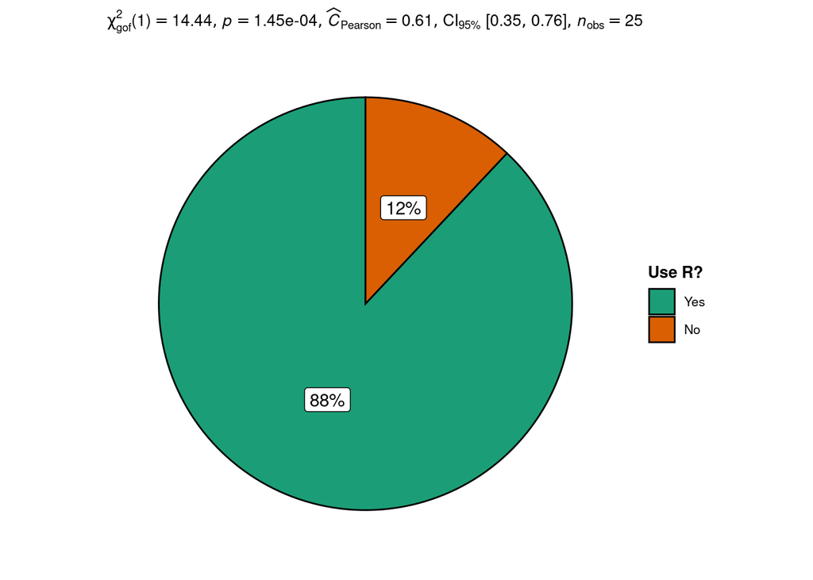

Figure 1: Pie chart and test statistics.

```r
ggpiestats( # creating the figure
  data = data, # data
  x = Response, # variable
  bf.message = FALSE, # Bayes Factor
  legend.title = "Use R?" # legend name
)
```

**One-Sided**

### Research Question

Is the preference of using R greater than the expected preference proportion of 50%?

### Hypothesis and Test Statistics

- $H_0:p=50\%$; the preference of using R is equal to the expected preference proportion of 50%.
- $H_a:p>50\%$; the preference of using R is greater than the expected preference proportion of 50%.
- Significance level, $\alpha=5\%$.
- **one proportion Z-test**
- Success-failure condition is met.

### Results and Interpretation

```r
prop.test(
  x = 22, # number of successes
  n = 25, # total number of trials (711 + 1490)
  p = 0.50, # expected preference proportion
  alternative = "greater" # other options: "two.sided" or "less"
)
```

```
    1-sample proportions test with continuity correction

data:  22 out of 25, null probability 0.5
X-squared = 12.96, df = 1, p-value = 0.0001591
alternative hypothesis: true p is greater than 0.5
95 percent confidence interval:
 0.7108563 1.0000000
sample estimates:
   p
0.88
```